# Assignment1-Lin-Twitter Data Wrangling and Visualization

# Data Visualization

-basic Plot to check on dispersion of values:

## Interpretation:

In the year 1941, Aircraft of Type “Transports” cost was higher with the least of Type “Trainers”

In the year 1942, Aircraft of Type “Transports” cost was higher with the least of Type “Trainers”

In the year 1943, Aircraft of Type “Transports” cost was higher with the least of Type “Trainers”

In the year 1944, Aircraft of Type “Heavy Bombers” cost was higher with the least of Type “Trainers”

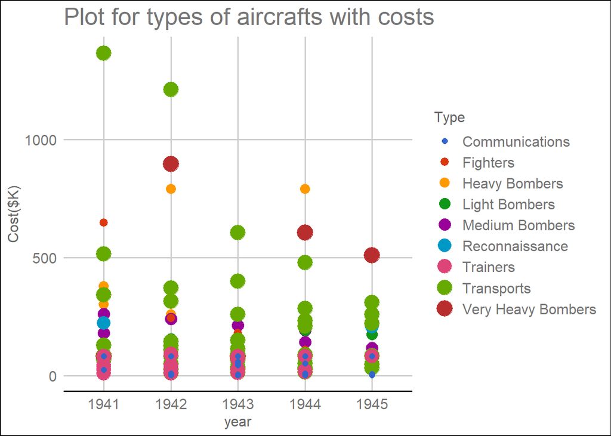

```r
ggplot(data = finaldf) +   geom_point(mapping = aes(x = year, y = Costs_without_null*0.001, color=Type,size = Type))+
  geom_smooth(mapping = aes(x = year, y = Costs_without_null, linetype = Type))+ ylab("Cost($K)")+ theme_gdocs() +  scale_color_gdocs()+
  ggtitle("Plot for types of aircrafts with costs")
```

## Point plot

-In-depth analysis of the costs when costs are split in facets when costs above average=T and below average= F

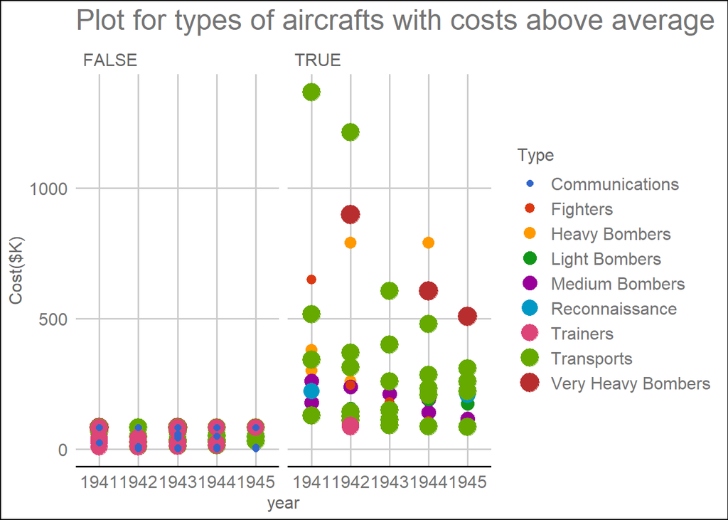

```r
#ggplot(data = finaldf) +   geom_smooth(mapping = aes(x = year, y = Costs_without_null*0.001, linetype = Type))
ggplot(data = finaldf) +   geom_point(mapping = aes(x = year, y = Costs_without_null*0.001, color=Type,size = Type))+
  geom_smooth(mapping = aes(x = year, y = Costs_without_null*0.001, linetype = Type))+
  facet_wrap(~costs_above_average)+ylab("Cost($K)")+ggtitle("Plot for types of aircrafts with costs above average")+
  theme_gdocs() +  scale_color_gdocs()
```

## Box Plot Interpretation

-Box plot with facets of costs and the year to get an idea on outliers

the outliers of communication types of Aircraft, Trainers has 2 outliers recorded in the year 1941, 1945 and 1942,1944 respectively.

the outliers of Aircraft type “Fighters”,“Light Bombers” has an outlier recorded in each year from 1941 - 1945

There are no outliers recorded for aircraft types- MEdium bombers, Heavy Bombers,Reconnaissance, Very Heavy Bombers.

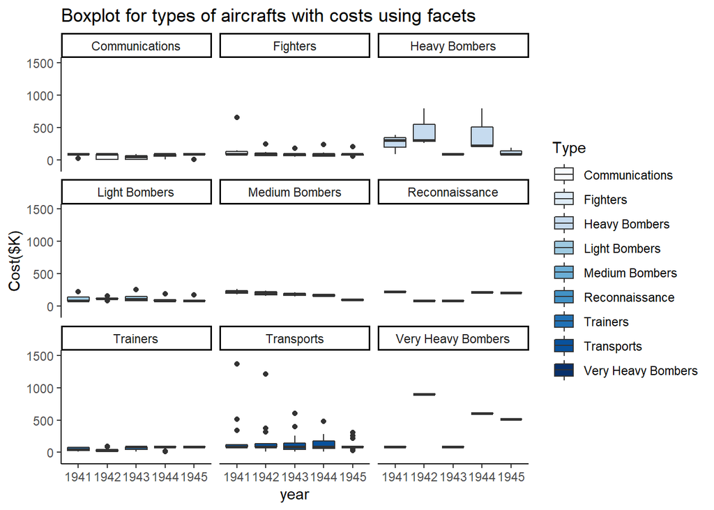

```r
ggplot(finaldf, aes(x=year, y=Costs_without_null*0.001,fill=Type)) + geom_boxplot()+theme_classic()+ facet_wrap(~ Type, nrow = 4, shrink = FALSE)+
  scale_fill_brewer(palette = "Blues")+ylab("Cost($K)")+ylim(-100,1500)+ ggtitle("Boxplot for types of aircrafts with costs using facets")
```

## Scatter Plot

-scatter plot with facets for more clear visualization of costs and the year with type as facets and their variations with each types

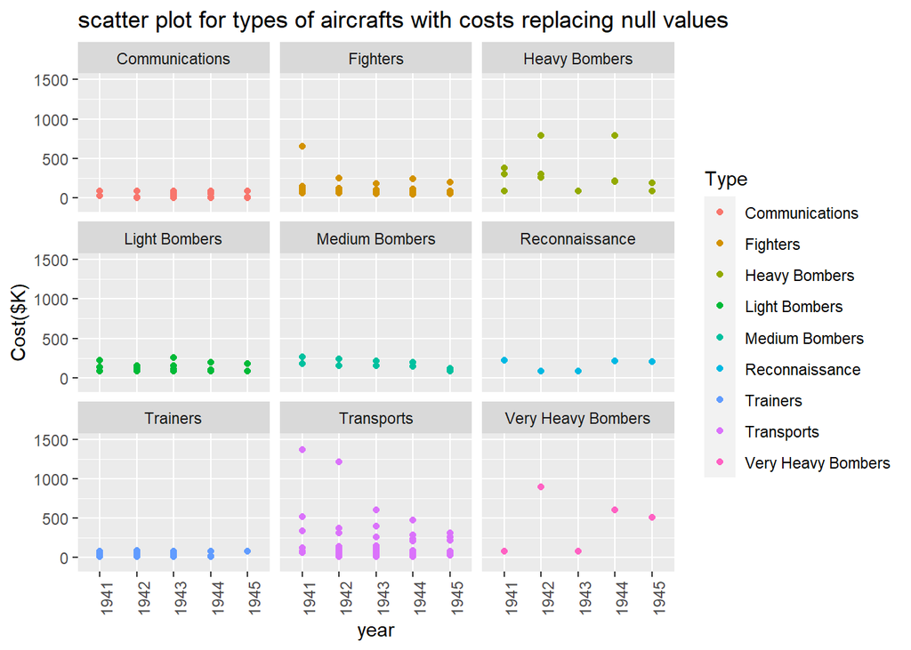

```r
scatter = ggplot(data = finaldf) +   geom_point(mapping = aes(x = year, y = Costs_without_null*0.001, color = Type))+
  facet_wrap(~ Type, nrow = 4, shrink = FALSE)+ ylab("Cost($K)")+ylim(-100,1500)
scatter +theme(axis.text.x = element_text(angle = 90))+ggtitle("scatter plot for types of aircrafts with costs replacing null values")
```